# The Anomaly

What an efficient plot can reveal

Christophe Bontemps (SIAP)

2026-11-04

## The source

From *William S. Cleveland* *Visualizing Data* (1993), Hobart Press, Summit, New Jersey

**The Data:** Barley Yield (bushels per acre)

- 10 barley varieties
- 6 sites in Minnesota
- 2 years: **1931** and **1932**

**Barley yields by site**

| Site | 1931 | 1932 |
| --- | --- | --- |
| Waseca | 54.3 | 41.9 |
| Crookston | 43.7 | 31.2 |
| Morris | 29.3 | 41.5 |
| University Farm | 35.8 | 29.5 |
| Duluth | 30.3 | 25.7 |
| Grand Rapids | 29.1 | 20.8 |

**Barley yields by variety**

| Variety | 1931 | 1932 |
| --- | --- | --- |
| Wisconsin No. 38 | 40.6 | 38.2 |
| Velvet | 34.5 | 31.6 |
| Trebi | 42.5 | 36.3 |
| Svansota | 34.0 | 26.7 |
| Peatland | 36.6 | 31.8 |
| No. 475 | 31.8 | 31.7 |
| No. 462 | 39.1 | 31.7 |
| No. 457 | 40.3 | 31.4 |
| Manchuria | 34.2 | 28.7 |
| Glabron | 37.3 | 29.4 |

Original data: Immer, Hayes & Powers (1934), *Journal of the American Society of Agronomy*, 26.

## Can you spot a problem? (*Original graphic*)

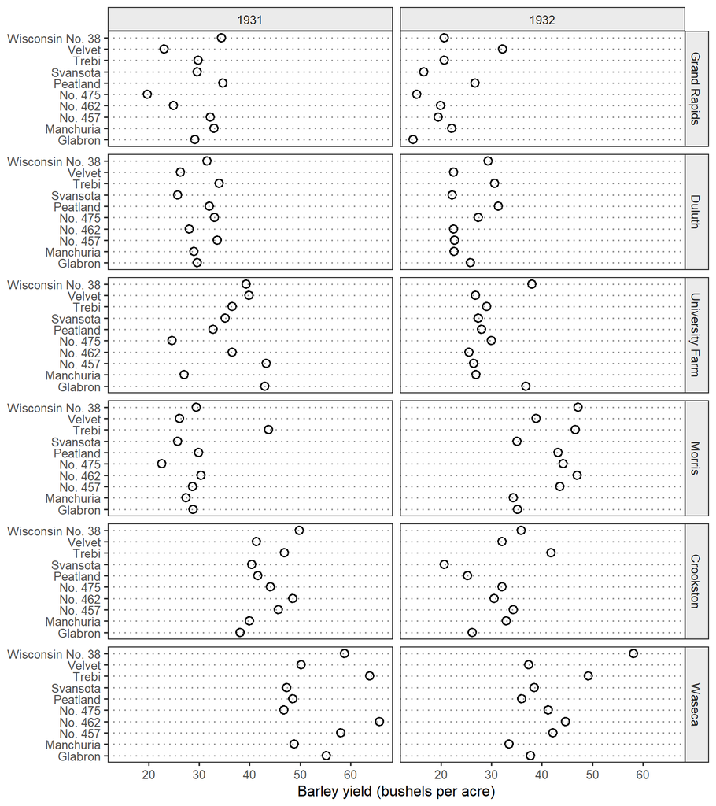

## Can you spot a problem? (modern graphic)

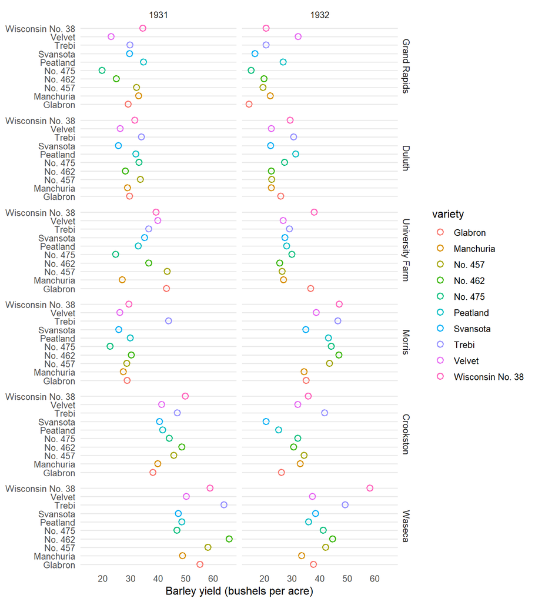

## Grouping points

Maybe grouping varieties can help?

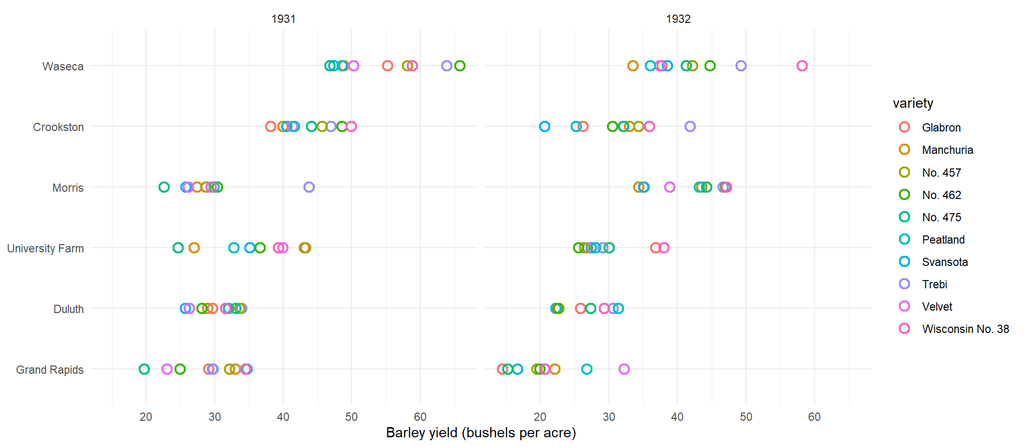

## Grouping points

Grouping varieties with *jitter*

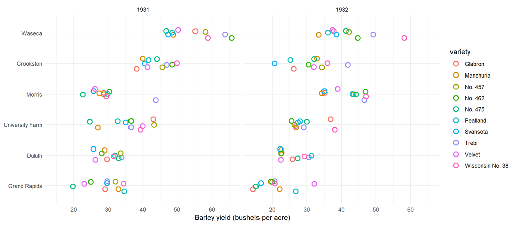

## Grouping points

Box-plot

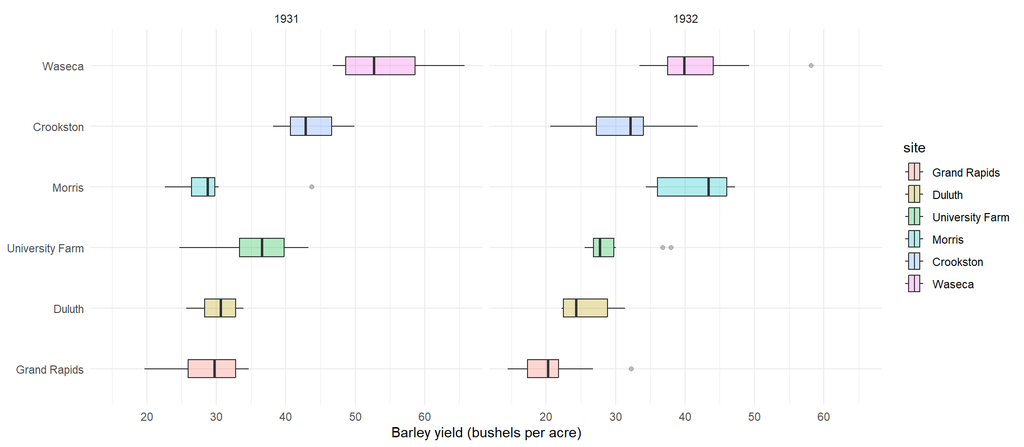

## Cleveland 1993’ Solution: Multiway dot plot

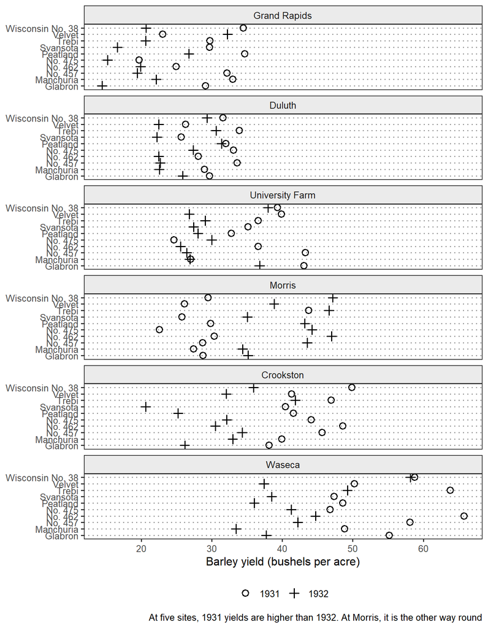

## Cleveland 1993’ Solution: modern version

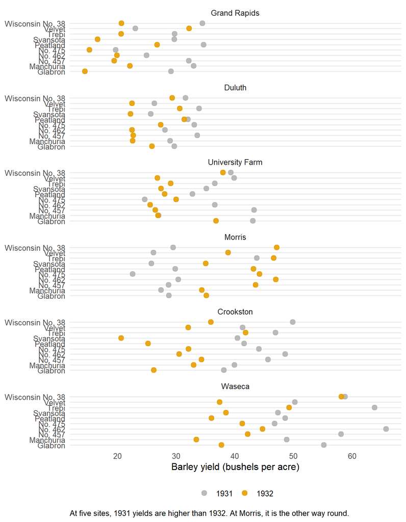

## Double lollipop: 1931 versus 1932

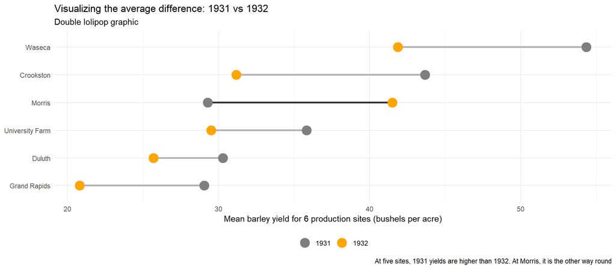

Only in **Morris** did production go **up** from 1931 to 1932.

## Lollipop: change in mean yield, 1932 − 1931

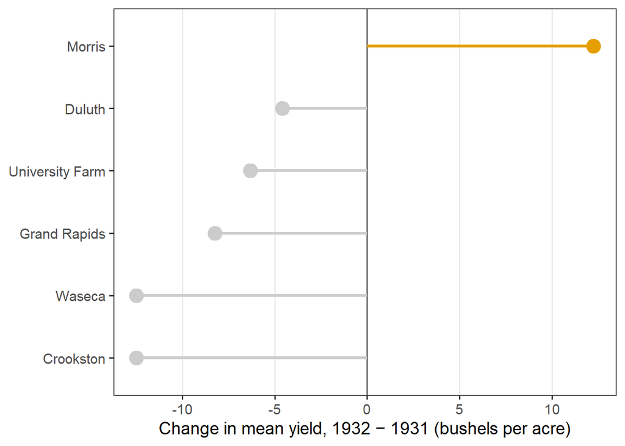

- Five sites: yield **falls** in 1932
- **Morris**: yield **rises** by about 12 bushels per acre
- Morris moves in the **opposite direction**, and by a similar magnitude to the other sites’ changes

## So what?

- **Tables** alone would hide this: Morris just looks like a site with a “good” 1932.
- The dot plots shows the **whole cloud of points, for each variety**
- **One color** (or shape) helps comparing years
- **Averages**, box an whiskers can hide errors
- Cleveland’s reading: the year labels for Morris were probably **swapped** in the data.

**Now that you saw it**

**Barley yields by site**

| Site | 1931 | 1932 |
| --- | --- | --- |
| Waseca | 54.3 | 41.9 |
| Crookston | 43.7 | 31.2 |
| Morris | 29.3 | 41.5 |
| University Farm | 35.8 | 29.5 |
| Duluth | 30.3 | 25.7 |
| Grand Rapids | 29.1 | 20.8 |

**A good graph is a tool for **checking the data**, not only for presenting results.**